# Tejon_Analysis_02162021

# Tick Density Relationships

### Dataset for tick density relationships

Lots of movin’ and groovin here. Trying to add multiple datasets together while avoiding duplication and too much observation lost

```r
##################################################################################################
# TICK COUNTS (YEAR, MONTH, PLOT, SITE)
#################################################################################################

# use cleaned up version that was used for mean tick count analyses = Tick
dim(Tick) # 1449 observations, 11 rows
```

```
## [1] 1449   11
```

```r
##################################################################################################
# CLIMATE (TEMP, PRECIP)
#################################################################################################

############## temperature ##############
temp <- read_csv("Tejon_temperature_02022021.csv")
temp.tick <- merge(Tick, temp)
dim(temp.tick) # 1449, 14 (added meanmaxF, meanminF, station)
```

```
## [1] 1449   14
```

```r
#View(temp.tick)

############## precipitation ##############

precip <- read_csv("tejon_tick_climate_10162020.csv")
precip_subset <- subset(precip, select = c(1:5,19,20))
names(precip_subset) <- tolower(names(precip_subset))
temp.tick.precip <- join(temp.tick, precip_subset)
dim(temp.tick.precip) #2025, 16 (added precip (in), precip (mm))
```

```
## [1] 2025   16
```

```r
names(temp.tick.precip)
```

```
##  [1] "year"        "month"       "site"        "block"       "plot"
##  [6] "total"       "deoc"        "ipac"        "deva"        "other"
## [11] "log_total"   "station"     "mean_maxF"   "mean_minF"   "precip (in)"
## [16] "precip (mm)"
```

```r
# seems like data got duplicated let's fix that

# best way is to remove duplicate rows which I lose ~50 observations but I think that is a better way to do it then extract unique elements by columns since alot of these observations are repetitive

temp.tick.prep.short <- temp.tick.precip %>%
  distinct()

dim(temp.tick.prep.short) # 1395, 16
```

```
## [1] 1395   16
```

```r
##################################################################################################
# VERTEBRATE (SPIECES RICHNESS, DIVERSITY, POP ESTIMATES)
#################################################################################################

############## mammal metrics ##############

mam <- read_csv("tejon_mammal_02022021.csv")
names(mam) <- tolower(names(mam))

climate.mam <- join(temp.tick.prep.short, mam)
dim(climate.mam) # 1895, 19 (added cum_mammal, shan_mammal, rich_mammal)
```

```
## [1] 1895   19
```

```r
# remove duplicate rows

climate.mam.short <- climate.mam %>%
  distinct()
dim(climate.mam.short) #1395, 19 # same amount of observations after climate dataset
```

```
## [1] 1395   19
```

```r
############## pop estimates ##############

pop_estimates <-read_csv("tejon_mamliz_popestimates.csv")
dim(pop_estimates) #27 5
```

```
## [1] 27  5
```

```r
climate.mam.combo <- join(climate.mam.short, pop_estimates)
dim(climate.mam.combo) # 1395   21 (added liz estimates, mam estimates)
```

```
## [1] 1395   21
```

```r
names(climate.mam.combo)[20] <- "liz_estimates"

dim(climate.mam.combo) # 1395   21
```

```
## [1] 1395   21
```

```r
names(climate.mam.combo)
```

```
##  [1] "year"          "month"         "site"          "block"
##  [5] "plot"          "total"         "deoc"          "ipac"
##  [9] "deva"          "other"         "log_total"     "station"
## [13] "mean_maxF"     "mean_minF"     "precip (in)"   "precip (mm)"
## [17] "cum_mammal"    "shan_mammal"   "rich_mammal"   "liz_estimates"
## [21] "mam_estimates"
```

```r
# let's shape this final sheet

## add some more metadata
# add Celcius
climate.mam.combo$mean_maxC <- (climate.mam.combo$mean_maxF - 32)*(5/9)
climate.mam.combo$mean_minC <- (climate.mam.combo$mean_minF - 32)*(5/9)


# add temperature difference
climate.mam.combo$tempdifF <- (climate.mam.combo$mean_maxF - climate.mam.combo$mean_minF)
climate.mam.combo$tempdifC <- (climate.mam.combo$mean_maxC - climate.mam.combo$mean_minC)



# add elevation
  climate.mam.combo$elevation <- climate.mam.combo$station
  climate.mam.combo$elevation[climate.mam.combo$station == "Lebec"] <- 1089.7
  climate.mam.combo$elevation[climate.mam.combo$station == "Loraine"] <- 1290.8
  climate.mam.combo$elevation[climate.mam.combo$station == "Chuchupate"] <- 1493.5

# add rain year
  # this is a dumb way but it is what it is
  climate.mam.combo$rain_year <- as.numeric(climate.mam.combo$year)
  climate.mam.combo$rain_year[climate.mam.combo$year == 2016 & climate.mam.combo$month == 'April'] <- "2015/2016"
  climate.mam.combo$rain_year[climate.mam.combo$year == 2016 & climate.mam.combo$month == 'May'] <- "2015/2016"
  climate.mam.combo$rain_year[climate.mam.combo$year == 2016 & climate.mam.combo$month == 'June'] <- "2015/2016"
  climate.mam.combo$rain_year[climate.mam.combo$year == 2016 & climate.mam.combo$month == 'July'] <- "2015/2016"
  climate.mam.combo$rain_year[climate.mam.combo$year == 2016 & climate.mam.combo$month == 'August'] <- "2015/2016"
  climate.mam.combo$rain_year[climate.mam.combo$year == 2016 & climate.mam.combo$month == 'September'] <- "2015/2016"
  climate.mam.combo$rain_year[climate.mam.combo$year == 2016 & climate.mam.combo$month == 'October'] <- "2015/2016"

  climate.mam.combo$rain_year[climate.mam.combo$year == 2016 & climate.mam.combo$month == 'November'] <- "2016/2017"
  climate.mam.combo$rain_year[climate.mam.combo$year == 2016 & climate.mam.combo$month == 'December'] <- "2016/2017"
  climate.mam.combo$rain_year[climate.mam.combo$year == 2017 & climate.mam.combo$month == 'January'] <- "2016/2017"
  climate.mam.combo$rain_year[climate.mam.combo$year == 2017 & climate.mam.combo$month == 'February'] <- "2016/2017"
  climate.mam.combo$rain_year[climate.mam.combo$year == 2017 & climate.mam.combo$month == 'March'] <- "2016/2017"
  climate.mam.combo$rain_year[climate.mam.combo$year == 2017 & climate.mam.combo$month == 'April'] <- "2016/2017"
  climate.mam.combo$rain_year[climate.mam.combo$year == 2017 & climate.mam.combo$month == 'May'] <- "2016/2017"
  climate.mam.combo$rain_year[climate.mam.combo$year == 2017 & climate.mam.combo$month == 'June'] <- "2016/2017"
  climate.mam.combo$rain_year[climate.mam.combo$year == 2017 & climate.mam.combo$month == 'July'] <- "2016/2017"
  climate.mam.combo$rain_year[climate.mam.combo$year == 2017 & climate.mam.combo$month == 'August'] <- "2016/2017"
  climate.mam.combo$rain_year[climate.mam.combo$year == 2017 & climate.mam.combo$month == 'September'] <- "2016/2017"
  climate.mam.combo$rain_year[climate.mam.combo$year == 2017 & climate.mam.combo$month == 'October'] <- "2016/2017"

  climate.mam.combo$rain_year[climate.mam.combo$year == 2017 & climate.mam.combo$month == 'November'] <- "2017/2018"
  climate.mam.combo$rain_year[climate.mam.combo$year == 2017 & climate.mam.combo$month == 'December'] <- "2017/2018"
  climate.mam.combo$rain_year[climate.mam.combo$year == 2018 & climate.mam.combo$month == 'January'] <- "2017/2018"
  climate.mam.combo$rain_year[climate.mam.combo$year == 2018 & climate.mam.combo$month == 'February'] <- "2017/2018"
  climate.mam.combo$rain_year[climate.mam.combo$year == 2018 & climate.mam.combo$month == 'March'] <- "2017/2018"
  climate.mam.combo$rain_year[climate.mam.combo$year == 2018 & climate.mam.combo$month == 'April'] <- "2017/2018"
  climate.mam.combo$rain_year[climate.mam.combo$year == 2018 & climate.mam.combo$month == 'May'] <- "2017/2018"
  climate.mam.combo$rain_year[climate.mam.combo$year == 2018 & climate.mam.combo$month == 'June'] <- "2017/2018"
  climate.mam.combo$rain_year[climate.mam.combo$year == 2018 & climate.mam.combo$month == 'July'] <- "2017/2018"
  climate.mam.combo$rain_year[climate.mam.combo$year == 2018 & climate.mam.combo$month == 'August'] <- "2017/2018"
  climate.mam.combo$rain_year[climate.mam.combo$year == 2018 & climate.mam.combo$month == 'September'] <- "2017/2018"
  climate.mam.combo$rain_year[climate.mam.combo$year == 2018 & climate.mam.combo$month == 'October'] <- "2017/2018"

  climate.mam.combo$rain_year[climate.mam.combo$year == 2018 & climate.mam.combo$month == 'November'] <- "2018/2019"
  climate.mam.combo$rain_year[climate.mam.combo$year == 2018 & climate.mam.combo$month == 'December'] <- "2018/2019"
  climate.mam.combo$rain_year[climate.mam.combo$year == 2019 & climate.mam.combo$month == 'January'] <- "2018/2019"
  climate.mam.combo$rain_year[climate.mam.combo$year == 2019 & climate.mam.combo$month == 'February'] <- "2018/2019"
  climate.mam.combo$rain_year[climate.mam.combo$year == 2019 & climate.mam.combo$month == 'March'] <- "2018/2019"
  climate.mam.combo$rain_year[climate.mam.combo$year == 2019 & climate.mam.combo$month == 'April'] <- "2018/2019"
  climate.mam.combo$rain_year[climate.mam.combo$year == 2019 & climate.mam.combo$month == 'May'] <- "2018/2019"
  climate.mam.combo$rain_year[climate.mam.combo$year == 2019 & climate.mam.combo$month == 'June'] <- "2018/2019"
  climate.mam.combo$rain_year[climate.mam.combo$year == 2019 & climate.mam.combo$month == 'July'] <- "2018/2019"
  climate.mam.combo$rain_year[climate.mam.combo$year == 2019 & climate.mam.combo$month == 'August'] <- "2018/2019"
  climate.mam.combo$rain_year[climate.mam.combo$year == 2019 & climate.mam.combo$month == 'September'] <- "2018/2019"
  climate.mam.combo$rain_year[climate.mam.combo$year == 2019 & climate.mam.combo$month == 'October'] <- "2018/2019"

  climate.mam.combo$rain_year[climate.mam.combo$year == 2019 & climate.mam.combo$month == 'November'] <- "2019/2020"
  climate.mam.combo$rain_year[climate.mam.combo$year == 2019 & climate.mam.combo$month == 'December'] <- "2019/2020"

# add plotID
climate.mam.combo <- transform(climate.mam.combo, plotidname = as.character(interaction(site, plot,block, drop = TRUE)))
climate.mam.combo <- transform(climate.mam.combo, plotID = as.numeric(interaction(site, plot,block, drop = TRUE)))
str(climate.mam.combo) # 1395 observations, 26 variables (added plotidname, plotID)
```

```
## 'data.frame':    1395 obs. of  29 variables:
##  $ year         : num  2016 2016 2016 2016 2016 ...
##  $ month        : chr  "April" "April" "April" "April" ...
##  $ site         : Factor w/ 3 levels "Arid","Intermediate",..: 1 1 1 1 1 1 1 1 1 2 ...
##  $ block        : num  2 2 2 1 1 1 3 3 3 3 ...
##  $ plot         : Factor w/ 3 levels "Open","Partial",..: 1 2 3 1 2 3 1 2 3 1 ...
##  $ total        : num  1 1 0 0 0 1 2 0 2 3 ...
##  $ deoc         : num  1 0 0 0 0 1 2 0 1 2 ...
##  $ ipac         : num  0 1 0 0 0 0 0 0 1 0 ...
##  $ deva         : num  0 0 0 0 0 0 0 0 0 1 ...
##  $ other        : num  0 0 0 0 0 0 0 0 0 0 ...
##  $ log_total    : num  0.693 0.693 0 0 0 ...
##  $ station      : chr  "Lebec" "Lebec" "Lebec" "Lebec" ...
##  $ mean_maxF    : num  66.3 66.3 66.3 66.3 66.3 66.3 66.3 66.3 66.3 64.9 ...
##  $ mean_minF    : num  43.1 43.1 43.1 43.1 43.1 43.1 43.1 43.1 43.1 39.6 ...
##  $ precip..in.  : num  0.57 0.57 0.57 0.57 0.57 0.57 0.57 0.57 0.57 1.64 ...
##  $ precip..mm.  : num  14.5 14.5 14.5 14.5 14.5 ...
##  $ cum_mammal   : num  13 42 34 13 42 34 13 42 34 8 ...
##  $ shan_mammal  : num  0.59 1 1.24 0.59 1 ...
##  $ rich_mammal  : num  2 4 4 2 4 4 2 4 4 2 ...
##  $ liz_estimates: num  61 73 61 52 74 68 83 70 89 208 ...
##  $ mam_estimates: num  6 46 41 2 16 16 3 NA 16 NA ...
##  $ mean_maxC    : num  19.1 19.1 19.1 19.1 19.1 ...
##  $ mean_minC    : num  6.17 6.17 6.17 6.17 6.17 ...
##  $ tempdifF     : num  23.2 23.2 23.2 23.2 23.2 23.2 23.2 23.2 23.2 25.3 ...
##  $ tempdifC     : num  12.9 12.9 12.9 12.9 12.9 ...
##  $ elevation    : chr  "1089.7" "1089.7" "1089.7" "1089.7" ...
##  $ rain_year    : chr  "2015/2016" "2015/2016" "2015/2016" "2015/2016" ...
##  $ plotidname   : chr  "Arid.Open.2" "Arid.Partial.2" "Arid.Total.2" "Arid.Open.1" ...
##  $ plotID       : num  10 13 16 1 4 7 19 22 25 20 ...
```

```r
# put data in right format
str(climate.mam.combo)
```

```
## 'data.frame':    1395 obs. of  29 variables:
##  $ year         : num  2016 2016 2016 2016 2016 ...
##  $ month        : chr  "April" "April" "April" "April" ...
##  $ site         : Factor w/ 3 levels "Arid","Intermediate",..: 1 1 1 1 1 1 1 1 1 2 ...
##  $ block        : num  2 2 2 1 1 1 3 3 3 3 ...
##  $ plot         : Factor w/ 3 levels "Open","Partial",..: 1 2 3 1 2 3 1 2 3 1 ...
##  $ total        : num  1 1 0 0 0 1 2 0 2 3 ...
##  $ deoc         : num  1 0 0 0 0 1 2 0 1 2 ...
##  $ ipac         : num  0 1 0 0 0 0 0 0 1 0 ...
##  $ deva         : num  0 0 0 0 0 0 0 0 0 1 ...
##  $ other        : num  0 0 0 0 0 0 0 0 0 0 ...
##  $ log_total    : num  0.693 0.693 0 0 0 ...
##  $ station      : chr  "Lebec" "Lebec" "Lebec" "Lebec" ...
##  $ mean_maxF    : num  66.3 66.3 66.3 66.3 66.3 66.3 66.3 66.3 66.3 64.9 ...
##  $ mean_minF    : num  43.1 43.1 43.1 43.1 43.1 43.1 43.1 43.1 43.1 39.6 ...
##  $ precip..in.  : num  0.57 0.57 0.57 0.57 0.57 0.57 0.57 0.57 0.57 1.64 ...
##  $ precip..mm.  : num  14.5 14.5 14.5 14.5 14.5 ...
##  $ cum_mammal   : num  13 42 34 13 42 34 13 42 34 8 ...
##  $ shan_mammal  : num  0.59 1 1.24 0.59 1 ...
##  $ rich_mammal  : num  2 4 4 2 4 4 2 4 4 2 ...
##  $ liz_estimates: num  61 73 61 52 74 68 83 70 89 208 ...
##  $ mam_estimates: num  6 46 41 2 16 16 3 NA 16 NA ...
##  $ mean_maxC    : num  19.1 19.1 19.1 19.1 19.1 ...
##  $ mean_minC    : num  6.17 6.17 6.17 6.17 6.17 ...
##  $ tempdifF     : num  23.2 23.2 23.2 23.2 23.2 23.2 23.2 23.2 23.2 25.3 ...
##  $ tempdifC     : num  12.9 12.9 12.9 12.9 12.9 ...
##  $ elevation    : chr  "1089.7" "1089.7" "1089.7" "1089.7" ...
##  $ rain_year    : chr  "2015/2016" "2015/2016" "2015/2016" "2015/2016" ...
##  $ plotidname   : chr  "Arid.Open.2" "Arid.Partial.2" "Arid.Total.2" "Arid.Open.1" ...
##  $ plotID       : num  10 13 16 1 4 7 19 22 25 20 ...
```

```r
climate.mam.combo$year <- as.factor(climate.mam.combo$year)
climate.mam.combo$block <- as.factor(climate.mam.combo$block)
climate.mam.combo$plotID <- as.factor(climate.mam.combo$plotID)
climate.mam.combo$rain_year <- as.factor(climate.mam.combo$rain_year)
climate.mam.combo$elevation <- as.numeric(climate.mam.combo$elevation)

climate.mam.combo$month <- factor(climate.mam.combo$month,
                        levels = c('January', 'February', 'March',
                                   'April', 'May', 'June', 'July',
                                   'August', 'September', 'October',
                                   'November', 'December'))
climate.mam.combo$site <- factor(climate.mam.combo$site,
                    levels = c('Arid', 'Intermediate', 'Mesic'))

climate.mam.combo$plot <- factor(climate.mam.combo$plot,
                    levels = c('Open', 'Partial', 'Total'))

# rename precip columns
names(climate.mam.combo)[15] <- "precip_in"
names(climate.mam.combo)[16] <- "precip_mm"


# Finally, the final dataset for GLMMS
FINAL <- climate.mam.combo
str(FINAL) # 1395 observations, 29 variables
```

```
## 'data.frame':    1395 obs. of  29 variables:
##  $ year         : Factor w/ 4 levels "2016","2017",..: 1 1 1 1 1 1 1 1 1 1 ...
##  $ month        : Factor w/ 12 levels "January","February",..: 4 4 4 4 4 4 4 4 4 4 ...
##  $ site         : Factor w/ 3 levels "Arid","Intermediate",..: 1 1 1 1 1 1 1 1 1 2 ...
##  $ block        : Factor w/ 3 levels "1","2","3": 2 2 2 1 1 1 3 3 3 3 ...
##  $ plot         : Factor w/ 3 levels "Open","Partial",..: 1 2 3 1 2 3 1 2 3 1 ...
##  $ total        : num  1 1 0 0 0 1 2 0 2 3 ...
##  $ deoc         : num  1 0 0 0 0 1 2 0 1 2 ...
##  $ ipac         : num  0 1 0 0 0 0 0 0 1 0 ...
##  $ deva         : num  0 0 0 0 0 0 0 0 0 1 ...
##  $ other        : num  0 0 0 0 0 0 0 0 0 0 ...
##  $ log_total    : num  0.693 0.693 0 0 0 ...
##  $ station      : chr  "Lebec" "Lebec" "Lebec" "Lebec" ...
##  $ mean_maxF    : num  66.3 66.3 66.3 66.3 66.3 66.3 66.3 66.3 66.3 64.9 ...
##  $ mean_minF    : num  43.1 43.1 43.1 43.1 43.1 43.1 43.1 43.1 43.1 39.6 ...
##  $ precip_in    : num  0.57 0.57 0.57 0.57 0.57 0.57 0.57 0.57 0.57 1.64 ...
##  $ precip_mm    : num  14.5 14.5 14.5 14.5 14.5 ...
##  $ cum_mammal   : num  13 42 34 13 42 34 13 42 34 8 ...
##  $ shan_mammal  : num  0.59 1 1.24 0.59 1 ...
##  $ rich_mammal  : num  2 4 4 2 4 4 2 4 4 2 ...
##  $ liz_estimates: num  61 73 61 52 74 68 83 70 89 208 ...
##  $ mam_estimates: num  6 46 41 2 16 16 3 NA 16 NA ...
##  $ mean_maxC    : num  19.1 19.1 19.1 19.1 19.1 ...
##  $ mean_minC    : num  6.17 6.17 6.17 6.17 6.17 ...
##  $ tempdifF     : num  23.2 23.2 23.2 23.2 23.2 23.2 23.2 23.2 23.2 25.3 ...
##  $ tempdifC     : num  12.9 12.9 12.9 12.9 12.9 ...
##  $ elevation    : num  1090 1090 1090 1090 1090 ...
##  $ rain_year    : Factor w/ 5 levels "2015/2016","2016/2017",..: 1 1 1 1 1 1 1 1 1 1 ...
##  $ plotidname   : chr  "Arid.Open.2" "Arid.Partial.2" "Arid.Total.2" "Arid.Open.1" ...
##  $ plotID       : Factor w/ 27 levels "1","2","3","4",..: 10 13 16 1 4 7 19 22 25 20 ...
```

```r
# write to an excel sheet
write.xlsx(FINAL, file = "Tejon_MixedModels_Dataset.xlsx",
           col.names = TRUE, row.names = TRUE)
```

#### **4.Correlation using Spearman’s rank**

Used non-parametric Spearman’s rank correlation. Looking at an association between the rank of tick counts and a potential predictor variables.

tick counts ~ potential predictors

- lizard population estimates
- temperature difference (C)
- monthly precipitation (mm)
- mammal population estimates
- mean max temperature (C)

```r
#cor.final <- subset(FINAL, select = c(11,20,21, 30)) # choosing variables of interest
#pairs.panels(cor.final)  # chose the variables that make the most sense for cor.test

cor.test(FINAL$total, FINAL$liz_estimate, method = "spearman", alternative = "two.sided")             # rho = .2187888  # p-value = 3.496e-11
```

```
##
##  Spearman's rank correlation rho
##
## data:  FINAL$total and FINAL$liz_estimate
## S = 93971029, p-value = 3.496e-11
## alternative hypothesis: true rho is not equal to 0
## sample estimates:
##       rho
## 0.2187888
```

```r
cor.test(FINAL$total, FINAL$tempdifC, method = "spearman", alternative = "two.sided")
```

```
##
##  Spearman's rank correlation rho
##
## data:  FINAL$total and FINAL$tempdifC
## S = 260111197, p-value = 4.643e-05
## alternative hypothesis: true rho is not equal to 0
## sample estimates:
##       rho
## 0.1168557
```

```r
# rho = 0.1168557 # p-value = 4.643e-05

cor.test(FINAL$total, FINAL$precip_mm, method = "spearman", alternative = "two.sided")
```

```
##
##  Spearman's rank correlation rho
##
## data:  FINAL$total and FINAL$precip_mm
## S = 149757667, p-value = 0.114
## alternative hypothesis: true rho is not equal to 0
## sample estimates:
##         rho
## -0.05133751
```

```r
# rho = - 0.05

cor.test(FINAL$total, FINAL$mam_estimates, method = "spearman", alternative = "two.sided")            # rho = .0240
```

```
##
##  Spearman's rank correlation rho
##
## data:  FINAL$total and FINAL$mam_estimates
## S = 185087917, p-value = 0.4376
## alternative hypothesis: true rho is not equal to 0
## sample estimates:
##        rho
## 0.02404853
```

```r
cor.test(FINAL$total, FINAL$mean_maxC, method = "spearman", alternative = "two.sided")
```

```
##
##  Spearman's rank correlation rho
##
## data:  FINAL$total and FINAL$mean_maxC
## S = 287494340, p-value = 0.4067
## alternative hypothesis: true rho is not equal to 0
## sample estimates:
##        rho
## 0.02388285
```

```r
# rho = 0.02388285


cor.test(FINAL$total, FINAL$shan_mammal, method = "spearman", alternative = "two.sided")             # rho = - 0.019
```

```
##
##  Spearman's rank correlation rho
##
## data:  FINAL$total and FINAL$shan_mammal
## S = 417966805, p-value = 0.4792
## alternative hypothesis: true rho is not equal to 0
## sample estimates:
##         rho
## -0.01927641
```

```r
cor.test(FINAL$total, FINAL$mean_minC, method = "spearman", alternative = "two.sided")
```

```
##
##  Spearman's rank correlation rho
##
## data:  FINAL$total and FINAL$mean_minC
## S = 303343382, p-value = 0.2984
## alternative hypothesis: true rho is not equal to 0
## sample estimates:
##         rho
## -0.02992872
```

```r
# rho = - .0299
```

#### **5.Generalized linear models (GLMs)**

tick counts ~ treatment

What happens if we just look at one treatment type? + Treatment 1: site as a proxy for climate + Treatment 2: plot as a proxy for host structure

*Site is a better predictor** Intercept = -0.26754 siteIntermediate estimate = 1.58575, p-value = < 0.0000000000000002 siteMesic estimate = 0.50949, p-value = 0.000000000000193 Null deviance: 7844.1 on 1349 degrees of freedom Residual deviance: 6717.4 on 1347 degrees of freedom AIC: 8320.7

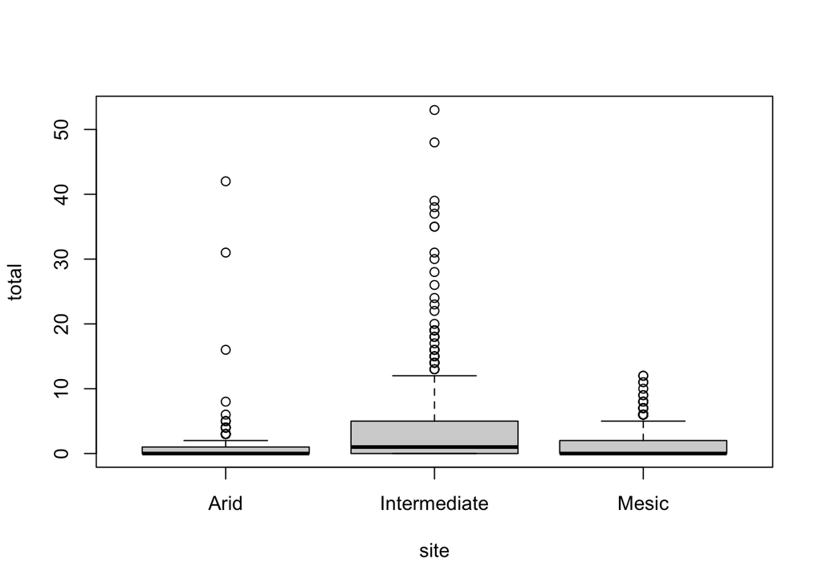

```r
boxplot(total ~ site, data = FINAL)
```

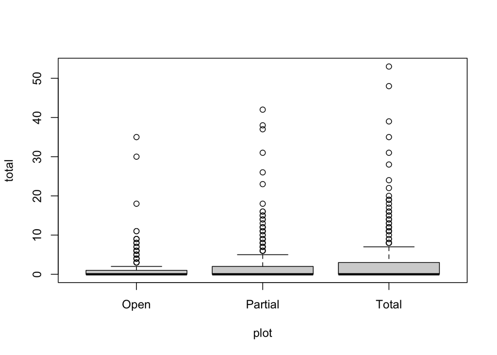

```r
boxplot(total ~ plot, data = FINAL)
```

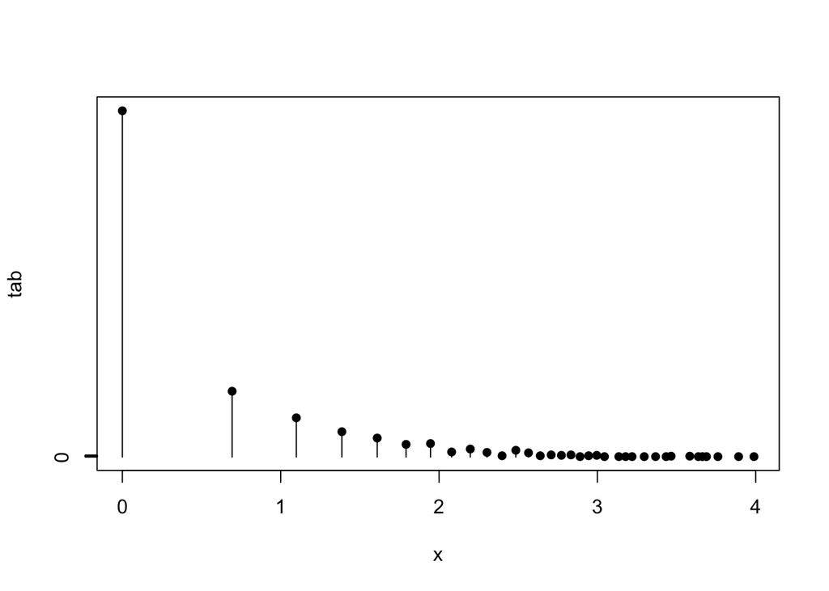

```r
tab <- xtabs(~log_total, data = FINAL)
x <- as.numeric(names(tab))
plot(x, tab, type = "h")
points(x, tab, pch = 16)
```

```r
mod.counts <- glm(total ~ site + plot,
                  family = poisson, data = FINAL)
summary(mod.counts)
```

```
##
## Call:
## glm(formula = total ~ site + plot, family = poisson, data = FINAL)
##
## Deviance Residuals:
##     Min       1Q   Median       3Q      Max
## -3.1990  -1.8587  -1.1745   0.3498  15.7518
##
## Coefficients:
##                  Estimate Std. Error z value Pr(>|z|)
## (Intercept)      -0.87776    0.06937 -12.653  < 2e-16 ***
## siteIntermediate  1.59222    0.06030  26.407  < 2e-16 ***
## siteMesic         0.50634    0.06929   7.308 2.71e-13 ***
## plotPartial       0.68120    0.05603  12.157  < 2e-16 ***
## plotTotal         0.91805    0.05408  16.976  < 2e-16 ***
## ---
## Signif. codes:  0 '***' 0.001 '**' 0.01 '*' 0.05 '.' 0.1 ' ' 1
##
## (Dispersion parameter for poisson family taken to be 1)
##
##     Null deviance: 7844.1  on 1349  degrees of freedom
## Residual deviance: 6389.0  on 1345  degrees of freedom
##   (45 observations deleted due to missingness)
## AIC: 7996.2
##
## Number of Fisher Scoring iterations: 6
```

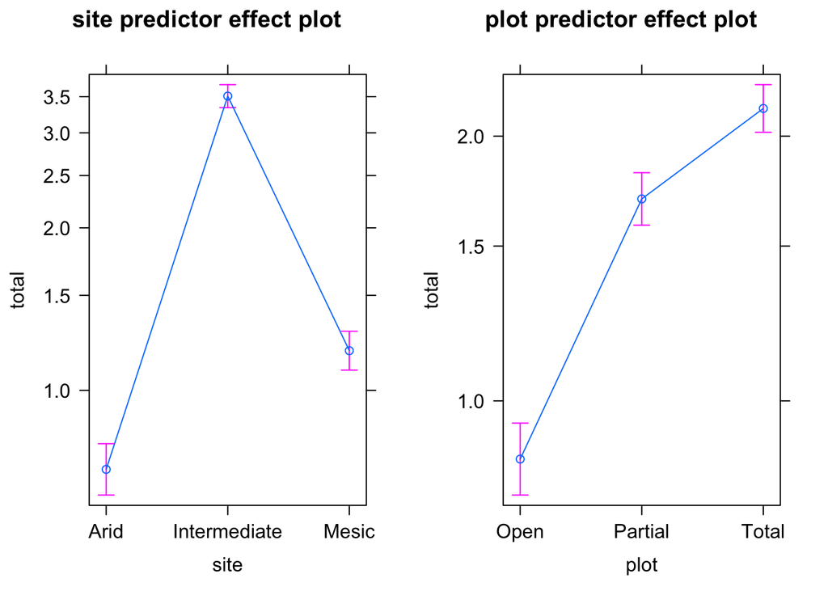

```r
plot(predictorEffects(mod.counts))
```

```r
# look at summary analyses
glm.site = glm(total ~ site, data = FINAL, family = "poisson")
summary(glm.site)
```

```
##
## Call:
## glm(formula = total ~ site, family = "poisson", data = FINAL)
##
## Deviance Residuals:
##     Min       1Q   Median       3Q      Max
## -2.7338  -1.5961  -1.2371   0.2561  15.9364
##
## Coefficients:
##                  Estimate Std. Error z value Pr(>|z|)
## (Intercept)      -0.26754    0.05538  -4.831 1.36e-06 ***
## siteIntermediate  1.58575    0.06029  26.300  < 2e-16 ***
## siteMesic         0.50949    0.06928   7.354 1.93e-13 ***
## ---
## Signif. codes:  0 '***' 0.001 '**' 0.01 '*' 0.05 '.' 0.1 ' ' 1
##
## (Dispersion parameter for poisson family taken to be 1)
##
##     Null deviance: 7844.1  on 1349  degrees of freedom
## Residual deviance: 6717.4  on 1347  degrees of freedom
##   (45 observations deleted due to missingness)
## AIC: 8320.7
##
## Number of Fisher Scoring iterations: 6
```

```r
# Intercept = -0.26754
# siteIntermediate estimate = 1.58575, p-value = < 0.0000000000000002
# siteMesic estimate = 0.50949, p-value = 0.000000000000193
# Null deviance: 7844.1  on 1349  degrees of freedom
# Residual deviance: 6717.4  on 1347  degrees of freedom
# AIC: 8320.7

glm.plot = glm(total ~ plot, data = FINAL, family = "poisson")
summary(glm.plot)
```

```
##
## Call:
## glm(formula = total ~ plot, family = "poisson", data = FINAL)
##
## Deviance Residuals:
##     Min       1Q   Median       3Q      Max
## -2.3141  -2.0572  -1.4744  -0.0846  14.6902
##
## Coefficients:
##             Estimate Std. Error z value Pr(>|z|)
## (Intercept)  0.08338    0.04588   1.817   0.0692 .
## plotPartial  0.66613    0.05603  11.889   <2e-16 ***
## plotTotal    0.90155    0.05407  16.672   <2e-16 ***
## ---
## Signif. codes:  0 '***' 0.001 '**' 0.01 '*' 0.05 '.' 0.1 ' ' 1
##
## (Dispersion parameter for poisson family taken to be 1)
##
##     Null deviance: 7844.1  on 1349  degrees of freedom
## Residual deviance: 7528.3  on 1347  degrees of freedom
##   (45 observations deleted due to missingness)
## AIC: 9131.6
##
## Number of Fisher Scoring iterations: 6
```

```r
# Intercept = 0.08338
# plotPartial estimate = 0.66613, p-value = <0.0000000000000002
# plotTotal estimate = 0.90155, p-value = <0.0000000000000002
# Null deviance: 7844.1  on 1349  degrees of freedom
# Residual deviance: 7528.3  on 1347  degrees of freedom
# AIC: 9131.6
```

#### **6.Negative binomial generalized linear mixed-models (NB GLMMs)

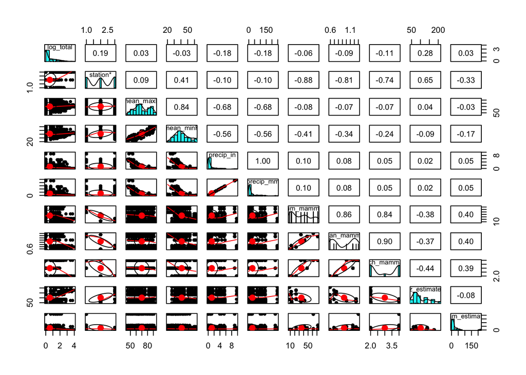

```r
final.plot <- subset(FINAL, select = c(11:21))
pairs.panels(final.plot) # makes sense that min-max, cum-shan, cum-rich are highly correlated, keep this in mind when building models
```

```r
## random effects models

# tick counts ~ climate + host, random = ~1|plotID + ~1|rain year
```

##### **6A. Climate models**

*Best model* gnb_mod3 <- glmer.nb(total ~ tempdifC + (1|plotID)+ (1|rain_year) + (1|month), data = na.omit(FINAL), family = “poisson”)

```r
######################## CLIMATE MODELS ########################
###### mean_maxF, mean_minF, tempdifF, mean_maxC, mean_minC, tempdifC, precip_in, precip_mm ####


str(FINAL)
```

```
## 'data.frame':    1395 obs. of  29 variables:
##  $ year         : Factor w/ 4 levels "2016","2017",..: 1 1 1 1 1 1 1 1 1 1 ...
##  $ month        : Factor w/ 12 levels "January","February",..: 4 4 4 4 4 4 4 4 4 4 ...
##  $ site         : Factor w/ 3 levels "Arid","Intermediate",..: 1 1 1 1 1 1 1 1 1 2 ...
##  $ block        : Factor w/ 3 levels "1","2","3": 2 2 2 1 1 1 3 3 3 3 ...
##  $ plot         : Factor w/ 3 levels "Open","Partial",..: 1 2 3 1 2 3 1 2 3 1 ...
##  $ total        : num  1 1 0 0 0 1 2 0 2 3 ...
##  $ deoc         : num  1 0 0 0 0 1 2 0 1 2 ...
##  $ ipac         : num  0 1 0 0 0 0 0 0 1 0 ...
##  $ deva         : num  0 0 0 0 0 0 0 0 0 1 ...
##  $ other        : num  0 0 0 0 0 0 0 0 0 0 ...
##  $ log_total    : num  0.693 0.693 0 0 0 ...
##  $ station      : chr  "Lebec" "Lebec" "Lebec" "Lebec" ...
##  $ mean_maxF    : num  66.3 66.3 66.3 66.3 66.3 66.3 66.3 66.3 66.3 64.9 ...
##  $ mean_minF    : num  43.1 43.1 43.1 43.1 43.1 43.1 43.1 43.1 43.1 39.6 ...
##  $ precip_in    : num  0.57 0.57 0.57 0.57 0.57 0.57 0.57 0.57 0.57 1.64 ...
##  $ precip_mm    : num  14.5 14.5 14.5 14.5 14.5 ...
##  $ cum_mammal   : num  13 42 34 13 42 34 13 42 34 8 ...
##  $ shan_mammal  : num  0.59 1 1.24 0.59 1 ...
##  $ rich_mammal  : num  2 4 4 2 4 4 2 4 4 2 ...
##  $ liz_estimates: num  61 73 61 52 74 68 83 70 89 208 ...
##  $ mam_estimates: num  6 46 41 2 16 16 3 NA 16 NA ...
##  $ mean_maxC    : num  19.1 19.1 19.1 19.1 19.1 ...
##  $ mean_minC    : num  6.17 6.17 6.17 6.17 6.17 ...
##  $ tempdifF     : num  23.2 23.2 23.2 23.2 23.2 23.2 23.2 23.2 23.2 25.3 ...
##  $ tempdifC     : num  12.9 12.9 12.9 12.9 12.9 ...
##  $ elevation    : num  1090 1090 1090 1090 1090 ...
##  $ rain_year    : Factor w/ 5 levels "2015/2016","2016/2017",..: 1 1 1 1 1 1 1 1 1 1 ...
##  $ plotidname   : chr  "Arid.Open.2" "Arid.Partial.2" "Arid.Total.2" "Arid.Open.1" ...
##  $ plotID       : Factor w/ 27 levels "1","2","3","4",..: 10 13 16 1 4 7 19 22 25 20 ...
```

```r
climate_gnbmod1 <- glmer.nb(total ~ mean_maxC + (1|plotID) + (1|rain_year) + (1|month),
                 data = na.omit(FINAL),
                 family = "poisson")


climate_gnbmod2 <- glmer.nb(total ~ mean_minC + (1|plotID)+ (1|rain_year) + (1|month),
                 data = na.omit(FINAL),
                 family = "poisson")

climate_gnbmod3 <- glmer.nb(total ~ tempdifC + (1|plotID)+ (1|rain_year) + (1|month),
                 data = na.omit(FINAL),
                 family = "poisson")

climate_gnbmod4 <- glmer.nb(total ~ precip_mm + (1|plotID)+ (1|rain_year) + (1|month),
                 data = na.omit(FINAL),
                 family = "poisson")

climate_gnbmod5 <- glmer.nb(total ~ mean_maxC + mean_minC + tempdifC +precip_mm +
                       (1|plotID)+ (1|rain_year) + (1|month),
                 data = na.omit(FINAL),
                 family = "poisson")

result <- AIC(climate_gnbmod1, climate_gnbmod2, climate_gnbmod3,climate_gnbmod4,climate_gnbmod5)
models <- list(climate_gnbmod1, climate_gnbmod2, climate_gnbmod3,climate_gnbmod4,climate_gnbmod5)



result$BIC <- sapply(models, BIC)
model_summary <- lapply(models, summary)
for(i in 1:(length(models)-1)){ #this creates a variable i that starts with the value i=1
  result$rsq[i] <- model_summary[[i]]$r.squared #we assign the rsq value from model i to the i'th row of the column 'rsq' in the table 'results'
  result$adj_rsq[i] <- model_summary[[i]]$adj.r.squared #same for adjusted rsq
} #now we go back to the beginning of the for-loop, add 1 to the value of i, and do everything again

result$variables <- c("maxC", "minC", "tempdiffC", "precip_mm", "Full")

climate_models <- kable(result, digits = 2, align = "c") %>%
  kable_styling()

### best fit model is gnb.mod3...difference in C based on BIC
```